# SOC-GA 2332 Intro to Stats Lab 8

Di Zhou

3/26/2021

### Part 1 Exercise 1 Answer

1.A. The regression equation for using Male and $D_\text{HS}$ as the reference:
$$Y = \beta_0 + \beta_1 D_\text{female} + \beta_2 D_\text{SC} + \beta_3 D_\text{BA} + \epsilon$$

1.B. The regression equation for using Male and $D_\text{SC}$ as the reference:
$$Y = \beta_0 + \beta_1 D_\text{female} + \beta_2 D_\text{HS} + \beta_3 D_\text{BA} + \epsilon$$

2. For all education levels, the gender gap is $\beta_1$.
3. For all education levels, the gender gap is $\beta_1$.
4. There is no difference.

### Part 1 Exercise 2 Answer

1.A. Using Male and $D_\text{HS}$ as the reference:

$$Y = \beta_0 + \beta_1 D_\text{female} + \beta_2 D_\text{SC} + \beta_3 D_\text{BA} + \beta_4 D_\text{female} D_\text{SC} + \beta_5 D_\text{female} D_\text{BA} + \epsilon$$

1.B. Using Male and $D_\text{SC}$ as the reference:

$$Y = \beta_0 + \beta_1 D_\text{female} + \beta_2 D_\text{HS} + \beta_3 D_\text{BA} + \beta_4 D_\text{female} D_\text{HS} + \beta_5 D_\text{female} D_\text{BA} + \epsilon$$

2.(i) For individuals with high school education, $\hat Y_\text{male, HS} = \beta_0$, $\hat Y_\text{female, HS} = \beta_0 + \beta_1$, so for equation (1.A.) the gender gap for people with high school education is $\beta_1$.

2.(ii) For individuals with some college education, $\hat Y_\text{male, SC} = \beta_0 + \beta_2$, $\hat Y_\text{female, SC} = \beta_0 + \beta_1 + \beta_2 + \beta_4$, so for equation (1.A.) the gender gap for people with some college education is $\beta_1 + \beta_4$.

2.(iii) For individuals with BA or higher education, $\hat Y_\text{male, BA} = \beta_0 + \beta_3$, $\hat Y_\text{female, BA} = \beta_0 + \beta_1 + \beta_3 + \beta_5$, so for equation (1.A.) the gender gap for people with BA or higher education is $\beta_1 + \beta_5$.

3.(i) For individuals with high school education, $\hat Y_\text{male, HS} = \beta_0 + \beta_2$, $\hat Y_\text{female, HS} = \beta_0 + \beta_1 + \beta_2 + \beta_4$, so for equation (1.B.) the gender gap for high school education is $\beta_1 + \beta_4$.

3.(ii) For individuals with some college education, $\hat Y_\text{male, SC} = \beta_0$, $\hat Y_\text{female, SC} = \beta_0 + \beta_1$, so for equation (1.B.) the gender gap for some college education is $\beta_1$.

3.(iii) For individuals with BA or higher education, $\hat Y_\text{male, BA} = \beta_0 + \beta_3$, $\hat Y_\text{female, BA} = \beta_0 + \beta_1 + \beta_3 + \beta_5$, so for equation (1.B.) the gender gap for BA education is $\beta_1 + \beta_5$.

4.Since 1e wants to test whether the gender gap differs between *those with some college* and *those with BA or higher*, **equation (1.B.) that uses $D_\text{SC}$ as the reference can help us answer the question**, because the difference in gender gap between people with some college and those with BA or higher is represented by **$\beta_5$**, where as in equation (1.A.) there is no single coefficient representing the difference in gender gap between the two categories in focus.

Note that for equation (1.A.), we CANNOT test whether $\beta_4 - \beta_5 = 0$ to derive whether the difference in gender gap between people with some college and those with BA or higher differs from zero, because the standard errors and t-values we get from the regression results are only for the value of each individual coefficient, not their difference.

The takeaway is that when you include interaction with dummy variables in your regression equation, the coefficient of the interaction terms represent the variation in effect **between your reference category and that specific non-reference category**, and you cannot directly compare the variation in effect between your non-reference category dummies because the regression result does not provide hypothesis testing for that.

### Part 2 Exercise

```r
# Estimate regression model
m1 <- lm(unemp ~ sch_high_q, unemploy_df)
m2 <- lm(unemp ~ sch_high_q + fam_inc, unemploy_df)
stargazer(m1, m2, type = "text")
```

```
##
## ====================================================================
##                                   Dependent variable:
##                     ------------------------------------------------
##                                          unemp
##                               (1)                     (2)
## --------------------------------------------------------------------
## sch_high_q                 -0.978***                -0.318**
##                             (0.158)                 (0.151)
##
## fam_inc                                            -0.471***
##                                                     (0.033)
##
## Constant                   15.546***               16.919***
##                             (0.082)                 (0.121)
##
## --------------------------------------------------------------------
## Observations                 1,000                   1,000
## R2                           0.037                   0.204
## Adjusted R2                  0.036                   0.203
## Residual Std. Error    2.215 (df = 998)         2.015 (df = 997)
## F Statistic         38.195*** (df = 1; 998) 127.981*** (df = 2; 997)
## ====================================================================
## Note:                                    *p<0.1; **p<0.05; ***p<0.01
```

The coefficient of school quality decreases from Model 1 to Model 2, because in Model 2, we controlled the confounder whose effect was expressed through school quality in Model 1. $R^2$ increases from Model 1 to Model 2, because we correctly included the confounder in our model whose variation explains more variation in Y compared to Model 1 that only include school quality as the IV.

2. According to the definition and equations we learned and using the simulate data, calculate (i) the Naive Estimator of ATE, (ii) treatment effect on the treated, and (iii) selection bias. How does these values compare? Interpret your results in a few words.

```r
# First, you can sort out the Ys based on treated or not & counterfactual or not
observed_treated <- unemploy_df %>% filter(sch_high_q == 1)
observed_control <- unemploy_df %>% filter(sch_high_q == 0)
counterfactual_treated <- unemploy_df %>% filter(sch_high_q_counterf == 0)
counterfactual_control <- unemploy_df %>% filter(sch_high_q_counterf == 1)

# Note that observed_control is the same as counterfactual_control,
# same for the other pair

# Naive Estimator of the Average Treatment Effect
mean(observed_treated$unemp) - mean(observed_control$unemp)
```

```
## [1] -0.9775141
```

```r
# Treatment effect on the treated
mean(observed_treated$unemp) - mean(counterfactual_treated$unemp_counterf)
```

```
## [1] -0.4000579
```

```r
# Selection bias
mean(counterfactual_treated$unemp_counterf) - mean(observed_control$unemp)
```

```
## [1] -0.5774562
```

The absolute value of the naive ATE is larger than the absolute value of the treatment effect on the treated. This is because those are selected to the treatment group tend to have a higher family income that helps reduce adulthood unemployment risk. Therefore, the actual effect of school quality on the treated group is smaller than the naive estimation.

### Part 3 Exercise

The screenshot is for reference only. For some variables, I included several options that you only need to pick one. Same for the 1970 samples.

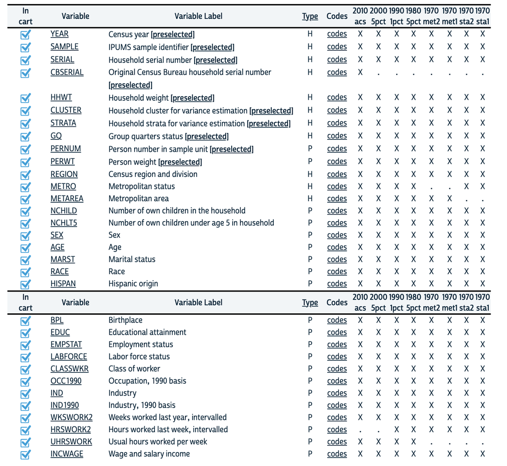